# Prediction methods

November 2, 2015

## Keep in mind

Classifier Technology and the Illusion of Progress

"A large number of comparative studies have been conducted in attempts to establish the relative superiority of these methods. This paper argues that these comparisons often fail to take into account important aspects of real problems, so that the apparent superiority of more sophisticated methods may be something of an illusion. In particular, simple methods typically yield performance almost as good as more sophisticated methods, to the extent that the difference in performance may be swamped by other sources of uncertainty that generally are not considered in the classical supervised classification paradigm."

http://arxiv.org/pdf/math/0606441.pdf

## The caret R package

[figure not shown]

http://caret.r-forge.r-project.org/

## Caret functionality

- Some preprocessing (cleaning)
- preProcess
- Data splitting
- createDataPartition
- createResample
- createTimeSlices
- Training/testing functions
- train
- predict
- Model comparison
- confusionMatrix

## Machine learning algorithms in R

- Linear discriminant analysis
- Regression
- Naive Bayes
- Support vector machines
- Classification and regression trees
- Random forests
- Boosting
- etc.

## Why caret?

[figure not shown]

## SPAM Example: Data splitting

```r
library(caret); library(kernlab); data(spam)
inTrain <- createDataPartition(y=spam$type,
                              p=0.75, list=FALSE)
training <- spam[inTrain,]
testing <- spam[-inTrain,]
dim(training)
```

```
## [1] 3451   58
```

## SPAM Example: Fit a model

```r
set.seed(32343)
modelFit <- train(type ~.,data=training, method="glm")
modelFit
```

```
## Generalized Linear Model
##
## 3451 samples
##   57 predictor
##    2 classes: 'nonspam', 'spam'
##
## No pre-processing
## Resampling: Bootstrapped (25 reps)
## Summary of sample sizes: 3451, 3451, 3451, 3451, 3451, 3451, ...
## Resampling results
##
##   Accuracy   Kappa      Accuracy SD  Kappa SD
##   0.9217714  0.8352108  0.006780095  0.01455116
##
##
```

## SPAM Example: Final model

```r
modelFit <- train(type ~.,data=training, method="glm")
modelFit$finalModel
```

```
##
## Call:  NULL
##
## Coefficients:
##       (Intercept)               make            address
##        -1.570e+00         -5.191e-01         -1.566e-01
##               all              num3d                our
##         1.615e-01          4.172e+00          5.615e-01
##              over             remove           internet
##         6.559e-01          1.967e+00          6.071e-01
##             order               mail            receive
##         7.252e-01          4.347e-01         -3.916e-02
##              will             people             report
##        -1.150e-01          2.947e-02          8.849e-02
##         addresses               free           business
##         1.941e+00          1.144e+00          8.463e-01
##             email                you             credit
##         1.441e-02          5.440e-02          1.022e+00
##              your               font             num000
##         2.489e-01          2.133e-01          2.120e+00
##             money                 hp                hpl
##         2.689e-01         -2.374e+00         -5.420e-01
##            george             num650                lab
##        -7.931e+00          5.045e-01         -2.050e+00
##              labs             telnet             num857
##        -2.689e-01         -1.531e-01          1.363e+00
##              data             num415              num85
##        -4.630e-01          8.970e-01         -2.178e+00
##        technology            num1999              parts
##         8.582e-01          1.910e-01         -7.073e-01
##                pm             direct                 cs
##        -8.829e-01         -3.279e-01         -4.480e+01
##           meeting           original            project
##        -2.958e+00         -1.415e+00         -1.946e+00
##                re                edu              table
##        -6.485e-01         -1.561e+00         -2.310e+00
##        conference      charSemicolon   charRoundbracket
##        -4.490e+00         -1.389e+00         -8.811e-01
## charSquarebracket    charExclamation         charDollar
##        -6.459e-01          7.873e-01          6.798e+00
##          charHash         capitalAve        capitalLong
##         2.645e+00         -9.430e-03          8.952e-03
##      capitalTotal
##         6.171e-04
##
## Degrees of Freedom: 3450 Total (i.e. Null);  3393 Residual
## Null Deviance:       4628
## Residual Deviance: 1323  AIC: 1439
```

## SPAM Example: Prediction

```r
predictions <- predict(modelFit,newdata=testing)
predictions
```

```
##    [1] spam    spam    spam    spam    spam    nonspam spam    spam
##    [9] spam    spam    spam    spam    spam    spam    spam    spam
##   [17] spam    spam    spam    spam    spam    spam    spam    spam
##   [25] spam    spam    spam    spam    nonspam nonspam spam    spam
##   [33] spam    nonspam spam    spam    spam    spam    spam    spam
##   [41] spam    spam    spam    spam    spam    spam    spam    spam
##   [49] spam    spam    spam    spam    spam    spam    spam    spam
##   [57] nonspam spam    spam    spam    spam    spam    spam    spam
##   [65] spam    spam    spam    spam    nonspam spam    spam    spam
##   [73] spam    spam    spam    spam    spam    spam    spam    spam
##   [81] spam    spam    spam    spam    spam    spam    spam    spam
##   [89] spam    spam    spam    spam    spam    spam    spam    spam
##   [97] spam    spam    spam    spam    spam    spam    spam    spam
##  [105] spam    spam    spam    spam    spam    spam    spam    spam
##  [113] spam    spam    spam    spam    spam    spam    spam    spam
```

[output cut: 130 more lines]

## SPAM Example: Confusion Matrix

```r
confusionMatrix(predictions,testing$type)
```

```
## Confusion Matrix and Statistics
##
##           Reference
## Prediction nonspam spam
##    nonspam     661   39
##    spam         36  414
##
##                Accuracy : 0.9348
##                  95% CI : (0.9189, 0.9484)
##     No Information Rate : 0.6061
##     P-Value [Acc > NIR] : <2e-16
##
##                   Kappa : 0.8633
##  Mcnemar's Test P-Value : 0.8174
##
##             Sensitivity : 0.9484
##             Specificity : 0.9139
##          Pos Pred Value : 0.9443
##          Neg Pred Value : 0.9200
##              Prevalence : 0.6061
##          Detection Rate : 0.5748
##    Detection Prevalence : 0.6087
##       Balanced Accuracy : 0.9311
##
##        'Positive' Class : nonspam
##
```

## SPAM Example: Data splitting

```r
library(caret); library(kernlab); data(spam)
inTrain <- createDataPartition(y=spam$type,
                              p=0.75, list=FALSE)
training <- spam[inTrain,]
testing <- spam[-inTrain,]
dim(training)
```

```
## [1] 3451   58
```

## SPAM Example: K-fold

```r
set.seed(32323)
folds <- createFolds(y=spam$type,k=10,
                             list=TRUE,returnTrain=TRUE)
sapply(folds,length)
```

```
## Fold01 Fold02 Fold03 Fold04 Fold05 Fold06 Fold07 Fold08 Fold09 Fold10
##   4141   4140   4141   4142   4140   4142   4141   4141   4140   4141
```

```r
folds[[1]][1:10]
```

```
##  [1]  1  2  3  4  5  6  7  8  9 10
```

## SPAM Example: Return test

```r
set.seed(32323)
folds <- createFolds(y=spam$type,k=10,
                             list=TRUE,returnTrain=FALSE)
sapply(folds,length)
```

```
## Fold01 Fold02 Fold03 Fold04 Fold05 Fold06 Fold07 Fold08 Fold09 Fold10
##    460    461    460    459    461    459    460    460    461    460
```

```r
folds[[1]][1:10]
```

```
##  [1] 24 27 32 40 41 43 55 58 63 68
```

## SPAM Example: Resampling

```r
set.seed(32323)
folds <- createResample(y=spam$type,times=10,
                             list=TRUE)
sapply(folds,length)
```

```
## Resample01 Resample02 Resample03 Resample04 Resample05 Resample06
##       4601       4601       4601       4601       4601       4601
## Resample07 Resample08 Resample09 Resample10
##       4601       4601       4601       4601
```

```r
folds[[1]][1:10]
```

```
##  [1]  1  2  3  3  3  5  5  7  8 12
```

## SPAM Example: Time Slices

```r
set.seed(32323)
tme <- 1:1000
folds <- createTimeSlices(y=tme,initialWindow=20,
                          horizon=10)
names(folds)
```

```
## [1] "train" "test"
```

```r
folds$train[[1]]
```

```
##  [1]  1  2  3  4  5  6  7  8  9 10 11 12 13 14 15 16 17 18 19 20
```

```r
folds$test[[1]]
```

```
##  [1] 21 22 23 24 25 26 27 28 29 30
```

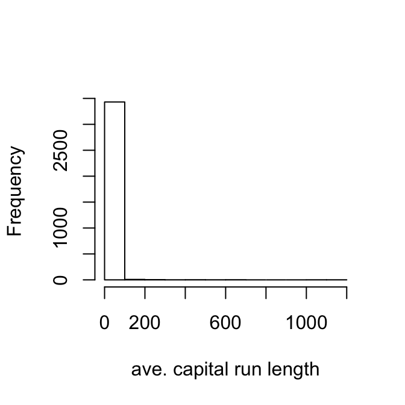

```r
library(caret); library(kernlab); data(spam)
inTrain <- createDataPartition(y=spam$type,
                              p=0.75, list=FALSE)
training <- spam[inTrain,]
testing <- spam[-inTrain,]
hist(training$capitalAve,main="",xlab="ave. capital run length")
```

## Why preprocess?

```r
mean(training$capitalAve)
```

```
## [1] 5.689484
```

```r
sd(training$capitalAve)
```

```
## [1] 36.07091
```

## Standardizing

```r
trainCapAve <- training$capitalAve
trainCapAveS <- (trainCapAve  - mean(trainCapAve))/sd(trainCapAve)
mean(trainCapAveS)
```

```
## [1] -1.113251e-17
```

```r
sd(trainCapAveS)
```

```
## [1] 1
```

## Standardizing - test set

```r
testCapAve <- testing$capitalAve
testCapAveS <- (testCapAve  - mean(trainCapAve))/sd(trainCapAve)
mean(testCapAveS)
```

```
## [1] -0.05523314
```

```r
sd(testCapAveS)
```

```
## [1] 0.3047389
```

## Standardizing - *preProcess* function

```r
preObj <- preProcess(training[,-58],method=c("center","scale"))
trainCapAveS <- predict(preObj,training[,-58])$capitalAve
mean(trainCapAveS)
```

```
## [1] -1.113251e-17
```

```r
sd(trainCapAveS)
```

```
## [1] 1
```

## Standardizing - *preProcess* function

```r
testCapAveS <- predict(preObj,testing[,-58])$capitalAve
mean(testCapAveS)
```

```
## [1] -0.05523314
```

```r
sd(testCapAveS)
```

```
## [1] 0.3047389
```

## Standardizing - *preProcess* argument

```r
set.seed(32343)
modelFit <- train(type ~.,data=training,
                  preProcess=c("center","scale"),method="glm")
modelFit
```

```
## Generalized Linear Model
##
## 3451 samples
##   57 predictor
##    2 classes: 'nonspam', 'spam'
##
## Pre-processing: centered (57), scaled (57)
## Resampling: Bootstrapped (25 reps)
## Summary of sample sizes: 3451, 3451, 3451, 3451, 3451, 3451, ...
## Resampling results
##
##   Accuracy  Kappa      Accuracy SD  Kappa SD
##   0.917132  0.8263397  0.01646928   0.03148507
##
##
```

## Standardizing - Box-Cox transforms

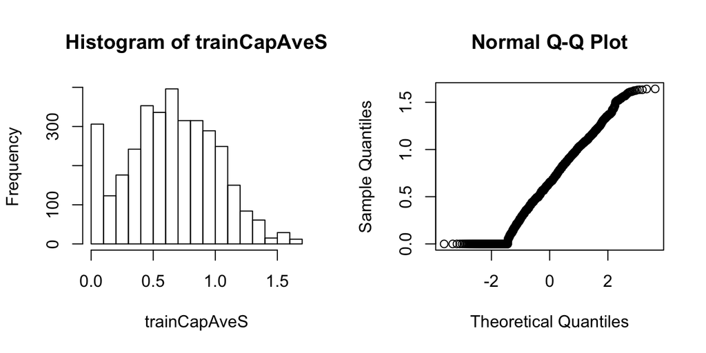

```r
preObj <- preProcess(training[,-58],method=c("BoxCox"))
trainCapAveS <- predict(preObj,training[,-58])$capitalAve
par(mfrow=c(1,2)); hist(trainCapAveS); qqnorm(trainCapAveS)
```

## Standardizing - Imputing data

```r
set.seed(13343)

# Make some values NA
training$capAve <- training$capitalAve
selectNA <- rbinom(dim(training)[1],size=1,prob=0.05)==1
training$capAve[selectNA] <- NA

# Impute and standardize
preObj <- preProcess(training[,-58],method="knnImpute")
capAve <- predict(preObj,training[,-58])$capAve

# Standardize true values
capAveTruth <- training$capitalAve
capAveTruth <- (capAveTruth-mean(capAveTruth))/sd(capAveTruth)
```

## Standardizing - Imputing data

```r
quantile(capAve - capAveTruth)
```

```
##            0%           25%           50%           75%          100%
## -0.9159720511  0.0009001442  0.0015826945  0.0019018727  1.4815904891
```

```r
quantile((capAve - capAveTruth)[selectNA])
```

```
##           0%          25%          50%          75%         100%
## -0.915972051 -0.017188800  0.002145162  0.013682239  1.481590489
```

```r
quantile((capAve - capAveTruth)[!selectNA])
```

```
##            0%           25%           50%           75%          100%
## -0.4895678551  0.0009412133  0.0015775609  0.0018783250  0.0021451624
```

## Correlated predictors

```r
library(caret); library(kernlab); data(spam)
inTrain <- createDataPartition(y=spam$type,
                              p=0.75, list=FALSE)
training <- spam[inTrain,]
testing <- spam[-inTrain,]

M <- abs(cor(training[,-58]))
diag(M) <- 0
which(M > 0.8,arr.ind=T)
```

```
##        row col
## num415  34  32
## direct  40  32
## num857  32  34
## direct  40  34
## num857  32  40
## num415  34  40
```

## Correlated predictors

```r
names(spam)[c(34,32)]
```

```
## [1] "num415" "num857"
```

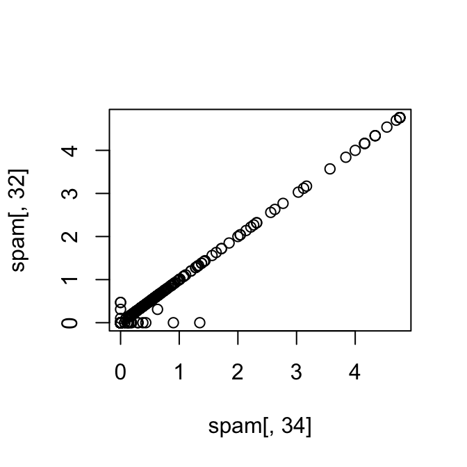

```r
plot(spam[,34],spam[,32])
```

## Basic PCA idea

- We might not need every predictor
- A weighted combination of predictors might be better
- We should pick this combination to capture the "most information" possible
- Benefits
- Reduced number of predictors
- Reduced noise (due to averaging)

## We could rotate the plot

\[ X = 0.71 \times {\rm num 415} + 0.71 \times {\rm num857}\]

\[ Y = 0.71 \times {\rm num 415} - 0.71 \times {\rm num857}\]

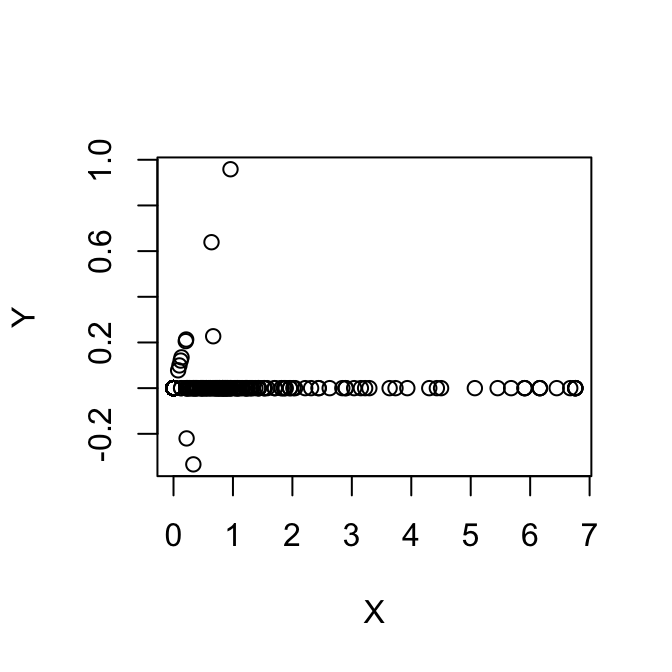

```r
X <- 0.71*training$num415 + 0.71*training$num857
Y <- 0.71*training$num415 - 0.71*training$num857
plot(X,Y)
```

## Related problems

You have multivariate variables \(X_1,\ldots,X_n\) so \(X_1 = (X_{11},\ldots,X_{1m})\)

- Find a new set of multivariate variables that are uncorrelated and explain as much variance as possible.
- If you put all the variables together in one matrix, find the best matrix created with fewer variables (lower rank) that explains the original data.

The first goal is statistical and the second goal is data compression.

## Related solutions - PCA/SVD

**SVD**

If \(X\) is a matrix with each variable in a column and each observation in a row then the SVD is a "matrix decomposition"

\[ X = UDV^T\]

where the columns of \(U\) are orthogonal (left singular vectors), the columns of \(V\) are orthogonal (right singluar vectors) and \(D\) is a diagonal matrix (singular values).

**PCA**

The principal components are equal to the right singular values if you first scale (subtract the mean, divide by the standard deviation) the variables.

## Principal components in R - prcomp

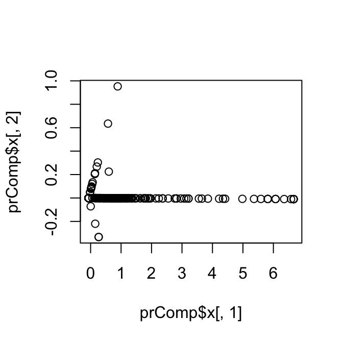

```r
smallSpam <- spam[,c(34,32)]
prComp <- prcomp(smallSpam)
plot(prComp$x[,1],prComp$x[,2])
```

## Principal components in R - prcomp

```r
prComp$rotation
```

```
##              PC1        PC2
## num415 0.7080625  0.7061498
## num857 0.7061498 -0.7080625
```

## PCA on SPAM data

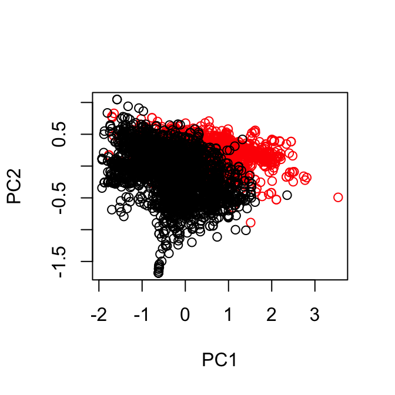

```r
typeColor <- ((spam$type=="spam")*1 + 1)
prComp <- prcomp(log10(spam[,-58]+1))
plot(prComp$x[,1],prComp$x[,2],col=typeColor,xlab="PC1",ylab="PC2")
```

## PCA with caret

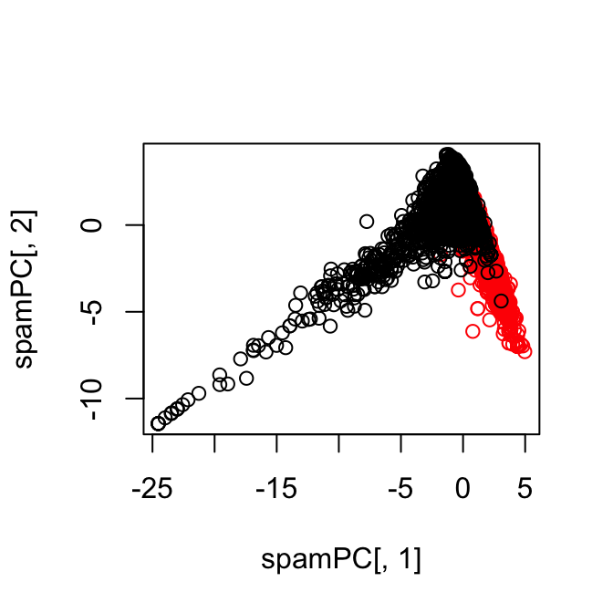

```r
preProc <- preProcess(log10(spam[,-58]+1),method="pca",pcaComp=2)
spamPC <- predict(preProc,log10(spam[,-58]+1))
plot(spamPC[,1],spamPC[,2],col=typeColor)
```

## Preprocessing with PCA

```r
preProc <- preProcess(log10(training[,-58]+1),method="pca",pcaComp=2)
trainPC <- predict(preProc,log10(training[,-58]+1))
modelFit <- train(training$type ~ .,method="glm",data=trainPC)
```

## Preprocessing with PCA

```r
testPC <- predict(preProc,log10(testing[,-58]+1))
confusionMatrix(testing$type,predict(modelFit,testPC))
```

```
## Confusion Matrix and Statistics
##
##           Reference
## Prediction nonspam spam
##    nonspam     636   61
##    spam         54  399
##
##                Accuracy : 0.9
##                  95% CI : (0.8812, 0.9167)
##     No Information Rate : 0.6
##     P-Value [Acc > NIR] : <2e-16
##
##                   Kappa : 0.7911
##  Mcnemar's Test P-Value : 0.5758
##
##             Sensitivity : 0.9217
##             Specificity : 0.8674
##          Pos Pred Value : 0.9125
##          Neg Pred Value : 0.8808
##              Prevalence : 0.6000
##          Detection Rate : 0.5530
##    Detection Prevalence : 0.6061
##       Balanced Accuracy : 0.8946
##
##        'Positive' Class : nonspam
##
```

## Alternative (sets # of PCs)

```r
modelFit <- train(training$type ~ .,method="glm",preProcess="pca",data=training)
confusionMatrix(testing$type,predict(modelFit,testing))
```

```
## Confusion Matrix and Statistics
##
##           Reference
## Prediction nonspam spam
##    nonspam     652   45
##    spam         39  414
##
##                Accuracy : 0.927
##                  95% CI : (0.9104, 0.9413)
##     No Information Rate : 0.6009
##     P-Value [Acc > NIR] : <2e-16
##
##                   Kappa : 0.8474
##  Mcnemar's Test P-Value : 0.5854
##
##             Sensitivity : 0.9436
##             Specificity : 0.9020
##          Pos Pred Value : 0.9354
##          Neg Pred Value : 0.9139
##              Prevalence : 0.6009
##          Detection Rate : 0.5670
##    Detection Prevalence : 0.6061
##       Balanced Accuracy : 0.9228
##
##        'Positive' Class : nonspam
##
```

## Predicting with trees

- Iteratively split variables into groups
- Split where maximally predictive
- Evaluate "homogeneity" within each branch
- Fitting multiple trees often works better (forests)

**Pros**: * Easy to implement * Easy to interpret * Better performance in nonlinear settings

**Cons**: * Without pruning/cross-validation can lead to overfitting * Harder to estimate uncertainty * Results may be variable

## Example Tree

[figure not shown]

http://graphics8.nytimes.com/images/2008/04/16/us/0416-nat-subOBAMA.jpg

## Basic algorithm

1. Start with all variables in one group
2. Find the variable/split that best separates the outcomes
3. Divide the data into two groups ("leaves") on that split ("node")
4. Within each split, find the best variable/split that separates the outcomes
5. Continue until the groups are too small or sufficiently "pure"

## Measures of impurity

\[\hat{p}_{mk} = \frac{1}{N_m}\sum_{x_i\; in \; Leaf \; m}\mathbb{1}(y_i = k)\]

**Misclassification Error**: \[ 1 - \hat{p}_{mk(m)}\]

**Gini index**: \[ \sum_{k \neq k'} \hat{p}_{mk} \times \hat{p}_{mk'} = \sum_{k=1}^K \hat{p}_{mk}(1-\hat{p}_{mk}) \]

**Cross-entropy or deviance**:

\[ -\sum_{k=1}^K \hat{p}_{mk} \ln\hat{p}_{mk} \]

## Example: Iris Data

```r
data(iris); library(ggplot2)
names(iris)
```

```
## [1] "Sepal.Length" "Sepal.Width"  "Petal.Length" "Petal.Width"
## [5] "Species"
```

```r
table(iris$Species)
```

```
##
##     setosa versicolor  virginica
##         50         50         50
```

## Create training and test sets

```r
inTrain <- createDataPartition(y=iris$Species,
                              p=0.7, list=FALSE)
training <- iris[inTrain,]
testing <- iris[-inTrain,]
dim(training); dim(testing)
```

```
## [1] 105   5
```

```
## [1] 45  5
```

## Iris petal widths/sepal width

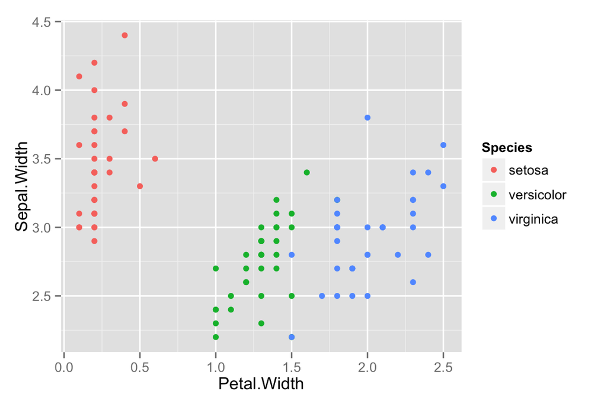

```r
qplot(Petal.Width,Sepal.Width,colour=Species,data=training)
```

## Iris petal widths/sepal width

```r
library(caret)
modFit <- train(Species ~ .,method="rpart",data=training)
print(modFit$finalModel)
```

```
## n= 105
##
## node), split, n, loss, yval, (yprob)
##       * denotes terminal node
##
## 1) root 105 70 setosa (0.33333333 0.33333333 0.33333333)
##   2) Petal.Length< 2.6 35  0 setosa (1.00000000 0.00000000 0.00000000) *
##   3) Petal.Length>=2.6 70 35 versicolor (0.00000000 0.50000000 0.50000000)
##     6) Petal.Length< 4.85 36  2 versicolor (0.00000000 0.94444444 0.05555556) *
##     7) Petal.Length>=4.85 34  1 virginica (0.00000000 0.02941176 0.97058824) *
```

## Plot tree

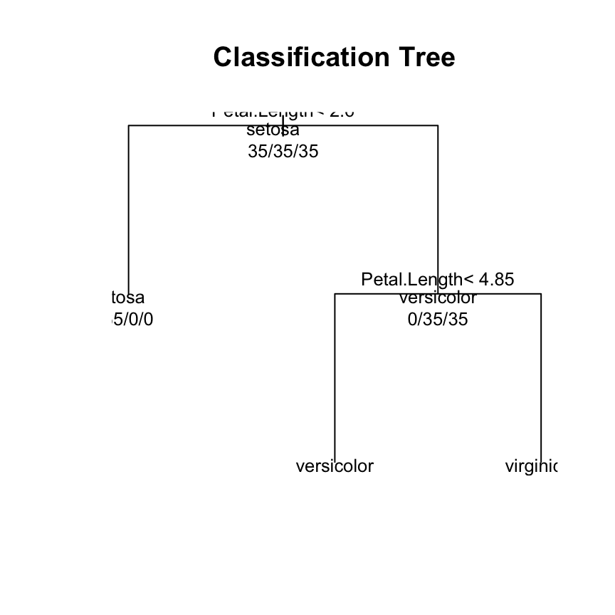

```r
plot(modFit$finalModel, uniform=TRUE,
      main="Classification Tree")
text(modFit$finalModel, use.n=TRUE, all=TRUE, cex=.8)
```

## Prettier plots

```r
library(rattle)
```

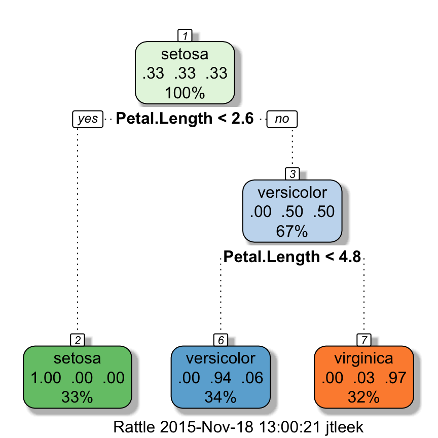

```r
fancyRpartPlot(modFit$finalModel)
```

## Predicting new values

```r
predict(modFit,newdata=testing)
```

```
##  [1] setosa     setosa     setosa     setosa     setosa     setosa
##  [7] setosa     setosa     setosa     setosa     setosa     setosa
## [13] setosa     setosa     setosa     versicolor virginica  versicolor
## [19] versicolor versicolor versicolor versicolor versicolor versicolor
## [25] virginica  versicolor versicolor virginica  versicolor versicolor
## [31] virginica  virginica  virginica  virginica  virginica  virginica
## [37] versicolor virginica  virginica  virginica  virginica  virginica
## [43] virginica  virginica  virginica
## Levels: setosa versicolor virginica
```

## Bootstrap aggregating (bagging)

**Basic idea**:

1. Resample cases and recalculate predictions
2. Average or majority vote

**Notes**:

- Similar bias
- Reduced variance
- More useful for non-linear functions

## Ozone data

```r
library(ElemStatLearn); data(ozone,package="ElemStatLearn")
ozone <- ozone[order(ozone$ozone),]
head(ozone)
```

```
##     ozone radiation temperature wind
## 17      1         8          59  9.7
## 19      4        25          61  9.7
## 14      6        78          57 18.4
## 45      7        48          80 14.3
## 106     7        49          69 10.3
## 7       8        19          61 20.1
```

http://en.wikipedia.org/wiki/Bootstrap_aggregating

## Bagged loess

```r
ll <- matrix(NA,nrow=10,ncol=155)
for(i in 1:10){
  ss <- sample(1:dim(ozone)[1],replace=T)
  ozone0 <- ozone[ss,]; ozone0 <- ozone0[order(ozone0$ozone),]
  loess0 <- loess(temperature ~ ozone,data=ozone0,span=0.2)
  ll[i,] <- predict(loess0,newdata=data.frame(ozone=1:155))
}
```

## Bagged loess

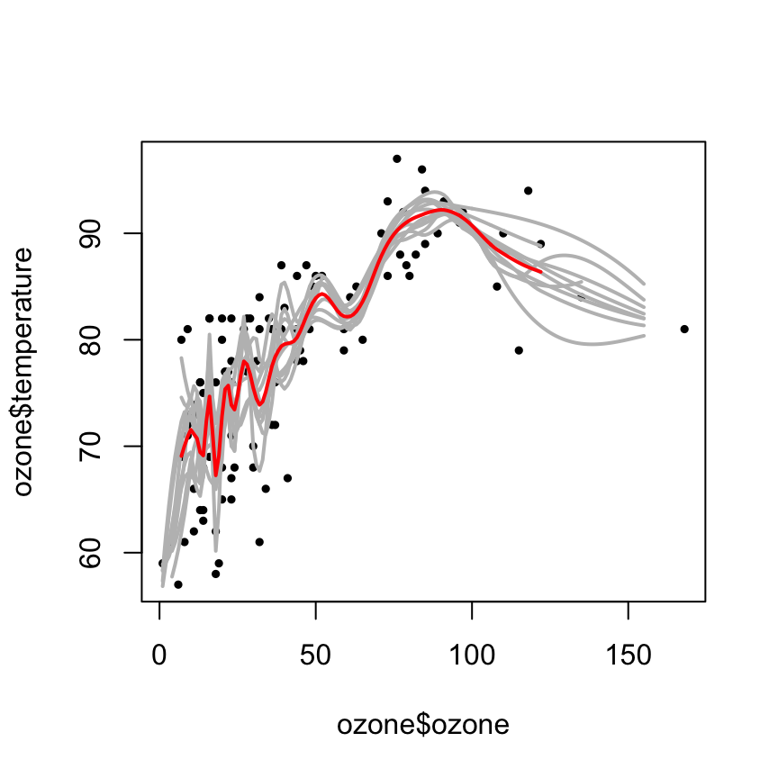

```r
plot(ozone$ozone,ozone$temperature,pch=19,cex=0.5)
for(i in 1:10){lines(1:155,ll[i,],col="grey",lwd=2)}
lines(1:155,apply(ll,2,mean),col="red",lwd=2)
```

## Random forests

1. Bootstrap samples
2. At each split, bootstrap variables
3. Grow multiple trees and vote

**Pros**:

1. Accuracy

**Cons**:

1. Speed
2. Interpretability
3. Overfitting

## Random forests

[figure not shown]

http://www.robots.ox.ac.uk/~az/lectures/ml/lect5.pdf

## Iris data

```r
data(iris); library(ggplot2)
inTrain <- createDataPartition(y=iris$Species,
                              p=0.7, list=FALSE)
training <- iris[inTrain,]
testing <- iris[-inTrain,]
```

## Random forests

```r
library(caret)
modFit <- train(Species~ .,data=training,method="rf",prox=TRUE)
modFit
```

```
## Random Forest
##
## 105 samples
##   4 predictor
##   3 classes: 'setosa', 'versicolor', 'virginica'
##
## No pre-processing
## Resampling: Bootstrapped (25 reps)
## Summary of sample sizes: 105, 105, 105, 105, 105, 105, ...
## Resampling results across tuning parameters:
##
##   mtry  Accuracy   Kappa      Accuracy SD  Kappa SD
##   2     0.9488901  0.9220177  0.02790868   0.04243993
##   3     0.9442339  0.9149999  0.02743107   0.04173570
##   4     0.9477479  0.9203104  0.02731673   0.04142538
##
## Accuracy was used to select the optimal model using  the largest value.
## The final value used for the model was mtry = 2.
```

## Getting a single tree

```r
library(randomForest)
getTree(modFit$finalModel,k=2)
```

```
##    left daughter right daughter split var split point status prediction
## 1              2              3         3        2.45      1          0
## 2              0              0         0        0.00     -1          1
## 3              4              5         3        4.75      1          0
## 4              0              0         0        0.00     -1          2
## 5              6              7         4        1.75      1          0
## 6              8              9         3        5.05      1          0
## 7              0              0         0        0.00     -1          3
## 8             10             11         1        6.35      1          0
## 9              0              0         0        0.00     -1          3
## 10             0              0         0        0.00     -1          3
## 11             0              0         0        0.00     -1          2
```

## Class "centers"

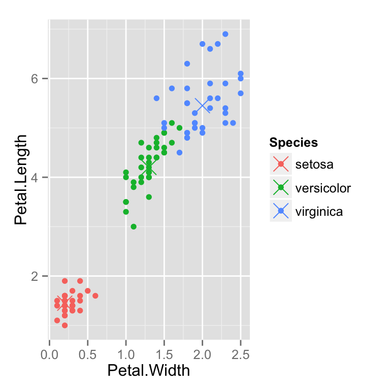

```r
irisP <- classCenter(training[,c(3,4)], training$Species, modFit$finalModel$prox)
irisP <- as.data.frame(irisP); irisP$Species <- rownames(irisP)
p <- qplot(Petal.Width, Petal.Length, col=Species,data=training)
p + geom_point(aes(x=Petal.Width,y=Petal.Length,col=Species),size=5,shape=4,data=irisP)
```

## Predicting new values

```r
pred <- predict(modFit,testing); testing$predRight <- pred==testing$Species
table(pred,testing$Species)
```

```
##
## pred         setosa versicolor virginica
##   setosa         15          0         0
##   versicolor      0         14         0
##   virginica       0          1        15
```

## Predicting new values

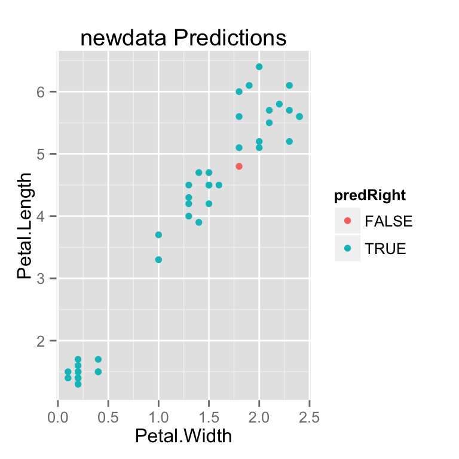

```r
qplot(Petal.Width,Petal.Length,colour=predRight,data=testing,main="newdata Predictions")
```

## Notes and further resources

**Notes**:

- Random forests are usually one of the two top performing algorithms along with boosting in prediction contests.
- Random forests are difficult to interpret but often very accurate.
- Care should be taken to avoid overfitting (see [rfcv](http://cran.r-project.org/web/packages/randomForest/randomForest.pdf) funtion)

**Further resources**:

- [Random forests](http://www.stat.berkeley.edu/~breiman/RandomForests/cc_home.htm)
- [Random forest Wikipedia](http://en.wikipedia.org/wiki/Random_forest)
- [Elements of Statistical Learning](http://www-stat.stanford.edu/~tibs/ElemStatLearn/)

## Naive Bayes

[figure not shown]

## Naive Bayes in R

```r
modFit <- train(Species~ .,data=training,method="nb",verbose=FALSE)
modFit
```

```
## Naive Bayes
##
## 105 samples
##   4 predictor
##   3 classes: 'setosa', 'versicolor', 'virginica'
##
## No pre-processing
## Resampling: Bootstrapped (25 reps)
## Summary of sample sizes: 105, 105, 105, 105, 105, 105, ...
## Resampling results across tuning parameters:
##
##   usekernel  Accuracy   Kappa      Accuracy SD  Kappa SD
##   FALSE      0.9282619  0.8910419  0.03478579   0.05239174
##    TRUE      0.9299476  0.8934132  0.03343620   0.05049823
##
## Tuning parameter 'fL' was held constant at a value of 0
## Accuracy was used to select the optimal model using  the largest value.
## The final values used for the model were fL = 0 and usekernel = TRUE.
```

## Strongest approach: averaging methods

- You can combine classifiers by averaging/voting
- Combining classifiers improves accuracy
- Combining classifiers reduces interpretability
- Boosting, bagging, and random forests are variants on this theme

## Netflix prize

BellKor = Combination of 107 predictors

[figure not shown]

http://www.netflixprize.com//leaderboard

## Heritage health prize - Progress Prize 1

[figure not shown]

[Market Makers](https://kaggle2.blob.core.windows.net/wiki-files/327/e4cd1d25-eca9-49ca-9593-b254a773fe03/Market%20Makers%20-%20Milestone%201%20Description%20V2%201.pdf)

[figure not shown]

[Mestrom](https://kaggle2.blob.core.windows.net/wiki-files/327/09ccf652-8c1c-4a3d-b979-ce2369c985e4/Willem%20Mestrom%20-%20Milestone%201%20Description%20V2%202.pdf)

## Basic intuition - majority vote

Suppose we have 5 completely independent classifiers

If accuracy is 70% for each: * \(10\times(0.7)^3(0.3)^2 + 5\times(0.7)^4(0.3)^2 + (0.7)^5\) * 83.7% majority vote accuracy

With 101 independent classifiers * 99.9% majority vote accuracy

## Approaches for combining classifiers

1. Bagging, boosting, random forests
- Usually combine similar classifiers
1. Combining different classifiers
- Model stacking
- Model ensembling

## Example with Wage data

**Create training, test and validation sets**

```r
library(ISLR); data(Wage); library(ggplot2); library(caret);
Wage <- subset(Wage,select=-c(logwage)); set.seed(132434)

# Create a building data set and validation set
inBuild <- createDataPartition(y=Wage$wage,
                              p=0.7, list=FALSE)
validation <- Wage[-inBuild,]; buildData <- Wage[inBuild,]

inTrain <- createDataPartition(y=buildData$wage,
                              p=0.7, list=FALSE)
training <- buildData[inTrain,]; testing <- buildData[-inTrain,]
```

## Wage data sets

**Create training, test and validation sets**

```r
dim(training)
```

```
## [1] 1474   11
```

```r
dim(testing)
```

```
## [1] 628  11
```

```r
dim(validation)
```

```
## [1] 898  11
```

## Build two different models

```r
mod1 <- train(wage ~.,method="glm",data=training)
mod2 <- train(wage ~.,method="rf",
              data=training,
              trControl = trainControl(method="cv"),number=3)
```

## Predict on the testing set

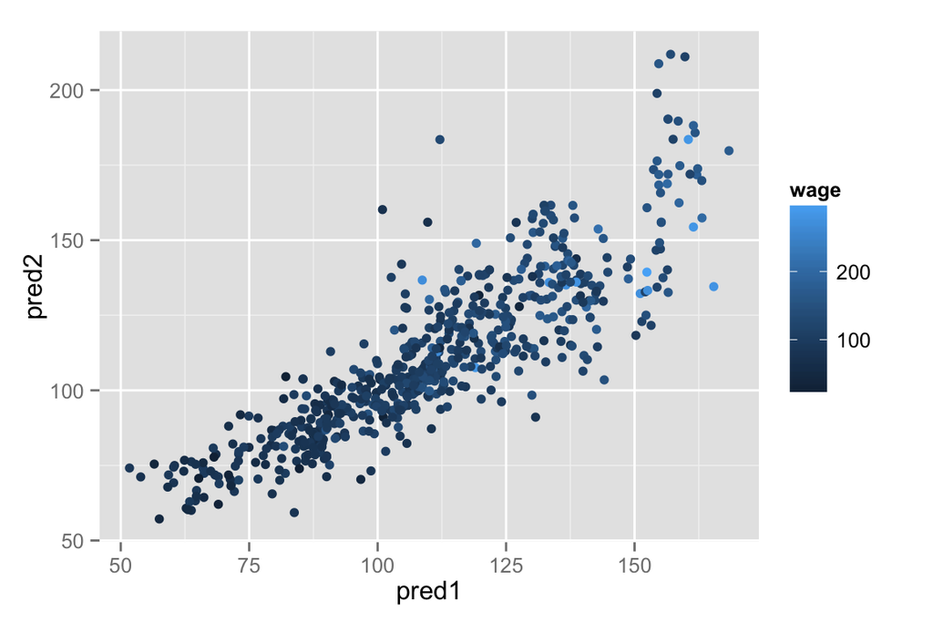

```r
pred1 <- predict(mod1,testing); pred2 <- predict(mod2,testing)
qplot(pred1,pred2,colour=wage,data=testing)
```

## Fit a model that combines predictors

```r
predDF <- data.frame(pred1,pred2,wage=testing$wage)
combModFit <- train(wage ~.,method="gam",data=predDF)
combPred <- predict(combModFit,predDF)
```

## Testing errors

```r
sqrt(sum((pred1-testing$wage)^2))
```

```
## [1] 772.7793
```

```r
sqrt(sum((pred2-testing$wage)^2))
```

```
## [1] 818.8482
```

```r
sqrt(sum((combPred-testing$wage)^2))
```

```
## [1] 758.2672
```

## Predict on validation data set

```r
pred1V <- predict(mod1,validation); pred2V <- predict(mod2,validation)
predVDF <- data.frame(pred1=pred1V,pred2=pred2V)
combPredV <- predict(combModFit,predVDF)
```

## Evaluate on validation

```r
sqrt(sum((pred1V-validation$wage)^2))
```

```
## [1] 1074.093
```

```r
sqrt(sum((pred2V-validation$wage)^2))
```

```
## [1] 1114.383
```

```r
sqrt(sum((combPredV-validation$wage)^2))
```

```
## [1] 1068.729
```

## Notes and further resources

- Even simple blending can be useful
- Typical model for binary/multiclass data
- Build an odd number of models
- Predict with each model
- Predict the class by majority vote
- This can get dramatically more complicated
- Simple blending in caret: caretEnsemble (use at your own risk!)

## Recall - scalability matters

[figure not shown]

http://www.techdirt.com/blog/innovation/articles/20120409/03412518422/

http://techblog.netflix.com/2012/04/netflix-recommendations-beyond-5-stars.html

## Basic idea behind boosting

1. Start with a set of classifiers \(h_1,\ldots,h_k\)
- Examples: All possible trees, all possible regression models, all possible cutoffs.
1. Create a classifier that combines classification functions: \(f(x) = \rm{sgn}\left(\sum_{t=1}^T \alpha_t h_t(x)\right)\).
- Goal is to minimize error (on training set)
- Iterative, select one \(h\) at each step
- Calculate weights based on errors
- Upweight missed classifications and select next \(h\)

[Adaboost on Wikipedia](http://en.wikipedia.org/wiki/AdaBoost)

http://webee.technion.ac.il/people/rmeir/BoostingTutorial.pdf

## Simple example

[figure not shown]

http://webee.technion.ac.il/people/rmeir/BoostingTutorial.pdf

## Round 1: adaboost

[figure not shown]

http://webee.technion.ac.il/people/rmeir/BoostingTutorial.pdf

## Round 2 & 3

[figure not shown]

http://webee.technion.ac.il/people/rmeir/BoostingTutorial.pdf

## Completed classifier

[figure not shown]

http://webee.technion.ac.il/people/rmeir/BoostingTutorial.pdf

## Boosting in R

- Boosting can be used with any subset of classifiers
- One large subclass is [gradient boosting](http://en.wikipedia.org/wiki/Gradient_boosting)
- R has multiple boosting libraries. Differences include the choice of basic classification functions and combination rules.
- [gbm](http://cran.r-project.org/web/packages/gbm/index.html) - boosting with trees.
- [mboost](http://cran.r-project.org/web/packages/mboost/index.html) - model based boosting
- [ada](http://cran.r-project.org/web/packages/ada/index.html) - statistical boosting based on [additive logistic regression](http://projecteuclid.org/DPubS?service=UI&version=1.0&verb=Display&handle=euclid.aos/1016218223)
- [gamBoost](http://cran.r-project.org/web/packages/GAMBoost/index.html) for boosting generalized additive models
- Most of these are available in the caret package

## Wage example

```r
library(ISLR); data(Wage); library(ggplot2); library(caret);
Wage <- subset(Wage,select=-c(logwage))
inTrain <- createDataPartition(y=Wage$wage,
                              p=0.7, list=FALSE)
training <- Wage[inTrain,]; testing <- Wage[-inTrain,]
```

## Fit the model

```r
modFit <- train(wage ~ ., method="gbm",data=training,verbose=FALSE)
print(modFit)
```

```
## Stochastic Gradient Boosting
##
## 2102 samples
##   10 predictor
##
## No pre-processing
## Resampling: Bootstrapped (25 reps)
## Summary of sample sizes: 2102, 2102, 2102, 2102, 2102, 2102, ...
## Resampling results across tuning parameters:
##
##   interaction.depth  n.trees  RMSE      Rsquared   RMSE SD   Rsquared SD
##   1                   50      35.47713  0.3175466  1.307227  0.02979723
##   1                  100      34.96486  0.3245110  1.279267  0.02773053
##   1                  150      34.88060  0.3261713  1.276890  0.02724611
##   2                   50      34.89711  0.3287960  1.318827  0.02995702
##   2                  100      34.71414  0.3327179  1.341760  0.02880713
##   2                  150      34.76814  0.3310188  1.329177  0.02812834
##   3                   50      34.75801  0.3318337  1.353888  0.03050635
##   3                  100      34.78617  0.3306917  1.345755  0.02894233
##   3                  150      34.93508  0.3263680  1.300269  0.02750901
##
## Tuning parameter 'shrinkage' was held constant at a value of 0.1
##
## Tuning parameter 'n.minobsinnode' was held constant at a value of 10
## RMSE was used to select the optimal model using  the smallest value.
## The final values used for the model were n.trees = 100,
##  interaction.depth = 2, shrinkage = 0.1 and n.minobsinnode = 10.
```

## Plot the results

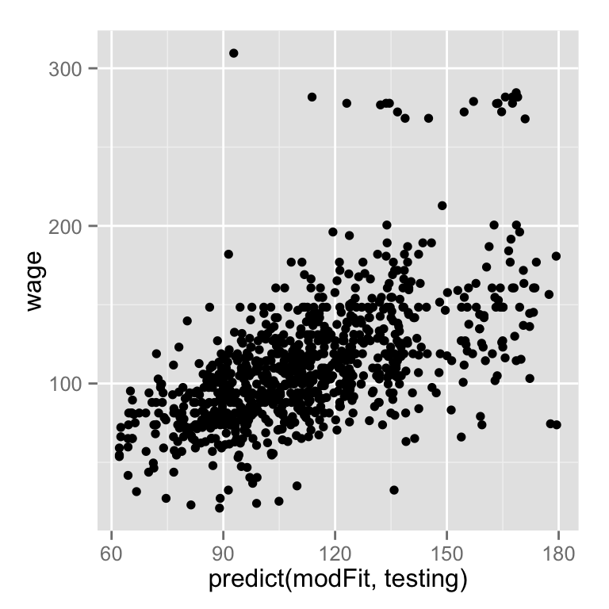

```r
qplot(predict(modFit,testing),wage,data=testing)
```

## Notes and further reading

- A couple of nice tutorials for boosting
- Freund and Shapire - http://www.cc.gatech.edu/~thad/6601-gradAI-fall2013/boosting.pdf
- Ron Meir- http://webee.technion.ac.il/people/rmeir/BoostingTutorial.pdf
- Boosting, random forests, and model ensembling are the most common tools that win Kaggle and other prediction contests.
- http://www.netflixprize.com/assets/GrandPrize2009_BPC_BigChaos.pdf
- https://kaggle2.blob.core.windows.net/wiki-files/327/09ccf652-8c1c-4a3d-b979-ce2369c985e4/Willem%20Mestrom%20-%20Milestone%201%20Description%20V2%202.pdf

## An example of least parametric to most

KNN -> Logistic Regression -> LDA -> Fully Bayesian model

- K nearest neighbors
- Logistic regression
- Linear discriminant analysis
- Fully Bayesian model

## KNN neighbors

Basic idea

\[\hat{Y}(x) = \frac{1}{k}\sum_{x_i \in N_k(x)} y_i\]

\[\hat{f}(x) = {\rm Ave}(y_i | x_i \in N_k(x))\]

[figure not shown]

http://statweb.stanford.edu/~tibs/ElemStatLearn/

## 1 nearest neighbor

[figure not shown]

http://statweb.stanford.edu/~tibs/ElemStatLearn/

## KNN for binary problem

\[\hat{Pr}(Y=k) = {\rm Ave}(1(y_i == k) | x_i \in N_k(x))\]

- Advantages
- Fully non-parametric
- Flexible
- Disadvantages
- Prone to overfitting
- Curse of dimensionality

## Logistic regression

Assume a model for \(Pr(Y=k | X=x)\)

\[ \rm{logit}Pr(Y = k |X = x) == x\beta\]

- Advantages
- Still doesn't assume model for \(x\)
- Can be more easily explained
- Disadvantages
- Lose flexibility
- Accuracy decreases when linear assumption isn't true

## Linear discriminant analysis

Build parametric model for conditional distribution \(P(Y = k | X = x)\)

\[Pr(Y = k | X=x) = \frac{f_k(x) \pi_k}{\sum_{\ell = 1}^K f_{\ell}(x) \pi_{\ell}}\]

- Classify to class with highest estimated probability
- Linear discriminant analysis assumes \(f_k(x)\) is multivariate Gaussian with same covariances
- Quadratic discrimant analysis assumes \(f_k(x)\) is multivariate Gaussian with different covariances
- You can assume more complicated distributions to get more complicated boundaries
- Naive Bayes would be assuming independence between features

http://statweb.stanford.edu/~tibs/ElemStatLearn/

## Why "linear" discriminant analysis?

\[log \frac{Pr(Y = k | X=x)}{Pr(Y = j | X=x)}\] \[ = log \frac{f_k(x)}{f_j(x)} + log \frac{\pi_k}{\pi_j}\] \[ = log \frac{\pi_k}{\pi_j} - \frac{1}{2}(\mu_k + \mu_j)^T \Sigma^{-1}(\mu_k + \mu_j)\] \[ + x^T \Sigma^{-1} (\mu_k - \mu_j)\]

## Decision boundaries

[figure not shown]

http://statweb.stanford.edu/~tibs/ElemStatLearn/

## Discriminant function

\[\delta_k(x) = x^T \Sigma^{-1} \mu_k - \frac{1}{2}\mu_k \Sigma^{-1}\mu_k + log(\mu_k)\]

- Decide on class based on \(\hat{Y}(x) = argmax_k \delta_k(x)\)
- We usually estimate parameters with maximum likelihood

## Logistic regression versus LDA

\[log \frac{Pr(Y = k | X=x)}{Pr(Y = j | X=x)}\] \[ = log \frac{\pi_k}{\pi_j} - \frac{1}{2}(\mu_k + \mu_j)^T \Sigma^{-1}(\mu_k + \mu_j)\] \[ + x^T \Sigma^{-1} (\mu_k - \mu_j)\] \[ = \alpha_{k0} + \alpha_k^Tx\]

Similarly from logistic regression

\[log \frac{Pr(Y = k | X=x)}{Pr(Y = j | X=x)} = \beta_{k0} + \beta_k^Tx\]

Both have same form for second term in this equation, but LDA assumes form for first term as well

\[Pr(X,Y=k) = Pr(X)Pr(Y=k|X)\]

http://statweb.stanford.edu/~tibs/ElemStatLearn/

## Model based prediction approach

- Assume that prior probability for a cluster is \(\pi_k\)
- Assume multivariate density for \(f(x | Y=k)\), usually normal
- Build a general model for \(\Sigma_k\) the conditional covariance
- Estimate the model with the EM approach

## Choices for covariance

[figure not shown]

## Bayes factors

\[B_{12} = \frac{Pr(X|M_1)}{Pr(X|M_2)}\]

where

\[Pr(X | M_k) = \int Pr(X | \theta_k M_k)Pr(\theta_k | M_k)d\theta_k\]

- Variables are then selected based on which model is "best" by this metric

## mclust package in R is where this is done

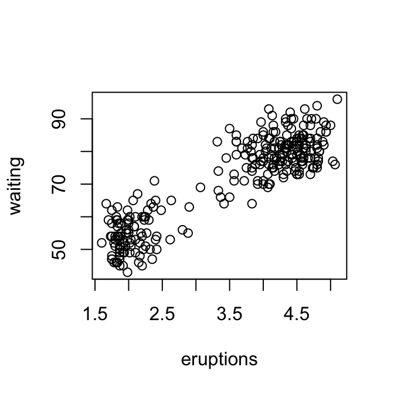

```r
library(mclust); data(faithful)
plot(faithful)
```

http://www.stat.washington.edu/mclust/

## mclust package in R is where this is done

```r
faithfulMclust <- Mclust(faithful)
summary(faithfulMclust)
```

```
## ----------------------------------------------------
## Gaussian finite mixture model fitted by EM algorithm
## ----------------------------------------------------
##
## Mclust EEE (ellipsoidal, equal volume, shape and orientation) model with 3 components:
##
##  log.likelihood   n df       BIC       ICL
##       -1126.361 272 11 -2314.386 -2360.865
##
## Clustering table:
##   1   2   3
## 130  97  45
```

http://www.stat.washington.edu/mclust/

## mclust package in R is where this is done

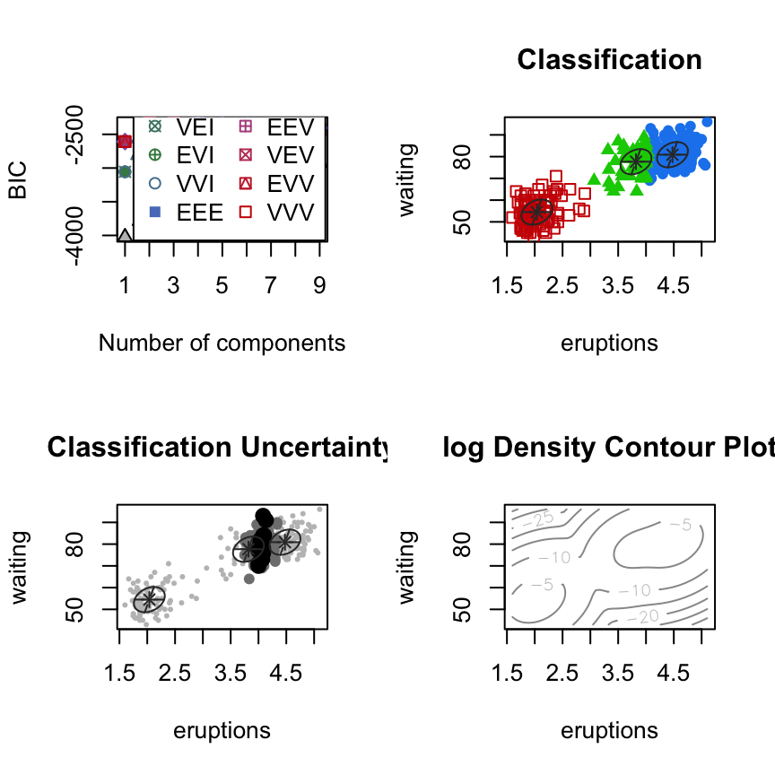

```r
par(mfrow=c(2,2))
plot(faithfulMclust)
```

http://www.stat.washington.edu/mclust/

## Model based clustering advantages and disadvantages

- Advantages
- Fully parametric so can compute all posterior quantities
- Can be a little more interpretable
- Disadvantages
- Much less flexible
- If your assumptions are wrong can be pretty far off

## Create training and test sets

```r
inTrain <- createDataPartition(y=iris$Species,
                              p=0.7, list=FALSE)
training <- iris[inTrain,]
testing <- iris[-inTrain,]
dim(training); dim(testing)
```

```
## [1] 105   5
```

```
## [1] 45  5
```

## Build predictions

```r
modlda = train(Species ~ .,data=training,method="lda")
modnb = train(Species ~ ., data=training,method="nb")
plda = predict(modlda,testing); pnb = predict(modnb,testing)
table(plda,pnb)
```

```
##             pnb
## plda         setosa versicolor virginica
##   setosa         15          0         0
##   versicolor      0         15         0
##   virginica       0          1        14
```

## Comparison of results

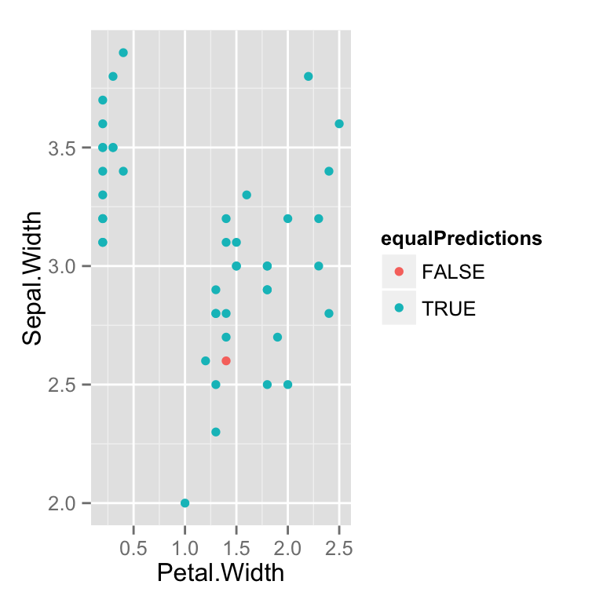

```r
equalPredictions = (plda==pnb)
qplot(Petal.Width,Sepal.Width,colour=equalPredictions,data=testing)
```

## Time series data

[figure not shown]

https://www.google.com/finance

## What is different?

- Data are dependent over time
- Specific pattern types
- Trends - long term increase or decrease
- Seasonal patterns - patterns related to time of week, month, year, etc.
- Cycles - patterns that rise and fall periodically
- Subsampling into training/test is more complicated
- Similar issues arise in spatial data
- Dependency between nearby observations
- Location specific effects
- Typically goal is to predict one or more observations into the future.
- All standard predictions can be used (with caution!)

## Beware spurious correlations!

[figure not shown]

http://www.google.com/trends/correlate

http://www.newscientist.com/blogs/onepercent/2011/05/google-correlate-passes-our-we.html

## Also common in geographic analyses

[figure not shown]

http://xkcd.com/1138/

## Beware extrapolation!

[figure not shown]

http://www.nature.com/nature/journal/v431/n7008/full/431525a.html

## Google data

```r
library(quantmod)
from.dat <- as.Date("01/01/08", format="%m/%d/%y")
to.dat <- as.Date("12/31/13", format="%m/%d/%y")
getSymbols("GOOG", src="google", from = from.dat, to = to.dat)
```

[output not shown]

```
## [1] "GOOG"
```

```r
head(GOOG)
```

```
##            GOOG.Open GOOG.High GOOG.Low GOOG.Close GOOG.Volume
## 2008-01-02    346.09    348.34   338.53     342.25          NA
## 2008-01-03    342.29    343.08   337.92     342.32          NA
## 2008-01-04    339.51    340.14   327.17     328.17          NA
## 2008-01-07    326.64    330.81   318.36     324.30          NA
## 2008-01-08    326.17    329.65   315.18     315.52          NA
## 2008-01-09    314.70    326.34   310.94     326.27          NA
```

## Summarize monthly and store as time series

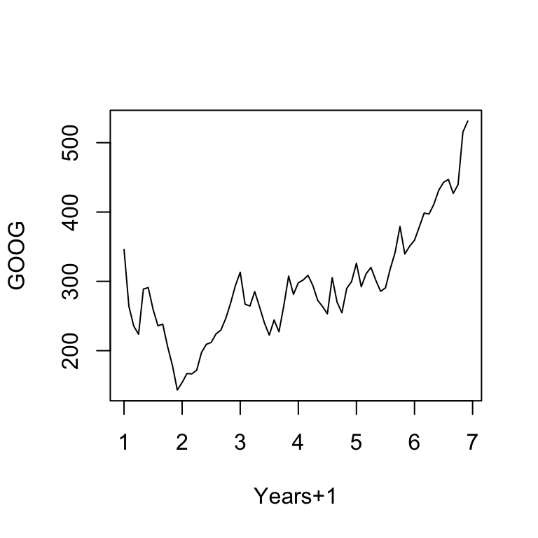

```r
googOpen <- Op(GOOG)
googOpen <- as.ts(Op(to.monthly(googOpen))[,1])
ts1 <- ts(googOpen,frequency=12)
plot(ts1,xlab="Years+1", ylab="GOOG")
```

## Example time series decomposition

- **Trend** - Consistently increasing pattern over time
- **Seasonal** - When there is a pattern over a fixed period of time that recurs.
- **Cyclic** - When data rises and falls over non fixed periods

https://www.otexts.org/fpp/6/1

## Decompose a time series into parts

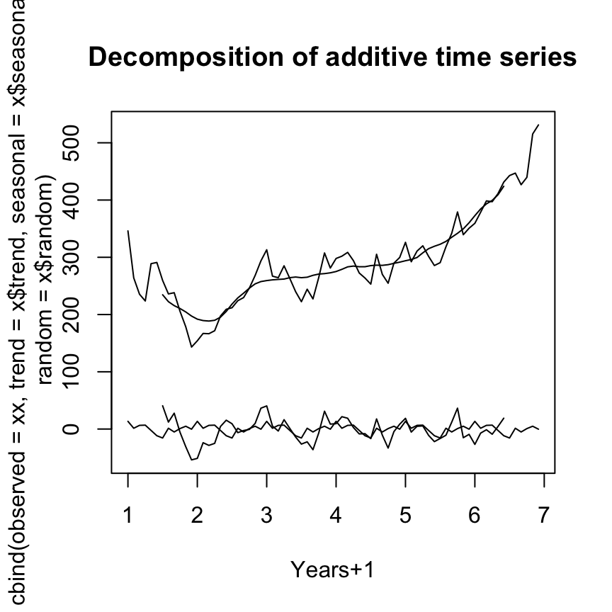

```r
plot(decompose(ts1),xlab="Years+1",plot.type="single")
```

## Training and test sets

```r
ts1Train <- window(ts1,start=1,end=5)
ts1Test <- window(ts1,start=5,end=(7-0.01))
ts1Train
```

```
##      Jan    Feb    Mar    Apr    May    Jun    Jul    Aug    Sep    Oct
## 1 346.09 264.07 235.52 223.65 288.87 290.96 259.53 236.02 238.15 205.86
## 2 154.15 166.98 166.50 171.72 197.32 209.16 211.89 224.15 229.61 246.25
## 3 313.16 267.03 264.34 285.16 262.99 239.97 222.42 244.25 227.26 264.74
## 4 297.94 301.94 308.58 294.09 272.58 263.76 253.12 305.30 270.10 254.67
## 5 326.14
##      Nov    Dec
## 1 178.61 143.20
## 2 268.27 293.77
## 3 307.56 281.22
## 4 289.76 299.70
## 5
```

## Simple moving average

\[ Y_{t}=\frac{1}{2*k+1}\sum_{j=-k}^k {y_{t+j}}\]

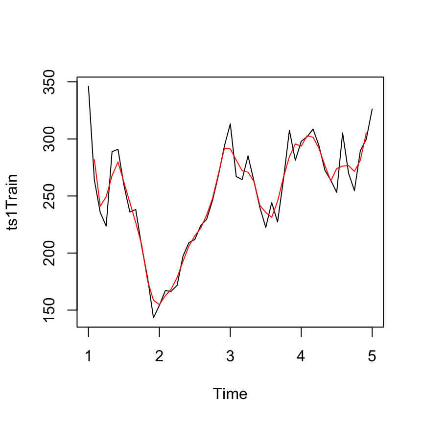

```r
library(forecast); plot(ts1Train)
lines(ma(ts1Train,order=3),col="red")
```

## Exponential smoothing

**Example - simple exponential smoothing** \[\hat{y}_{t+1} = \alpha y_t + (1-\alpha)\hat{y}_{t-1}\]

[figure not shown]

https://www.otexts.org/fpp/7/6

## A taxonomy of exponential smoothing methods

[figure not shown]

https://www.otexts.org/fpp/7/6

## Exponential smoothing

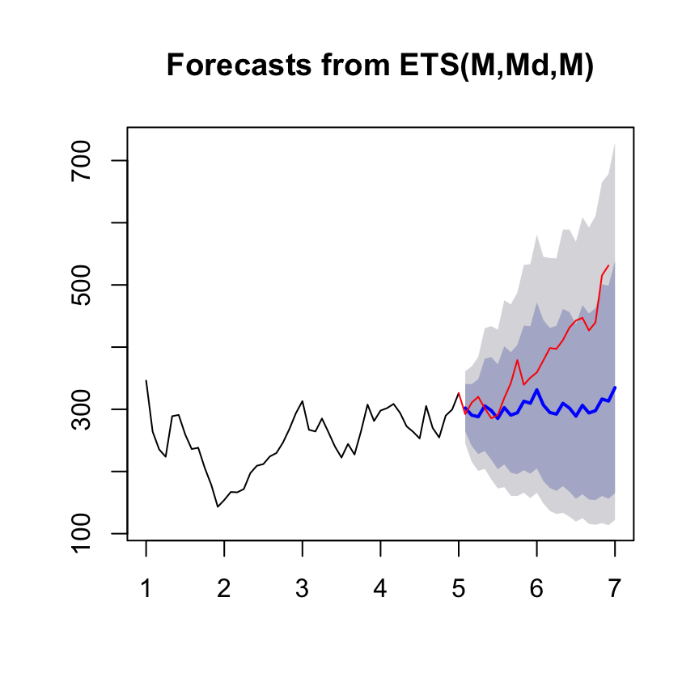

```r
ets1 <- ets(ts1Train,model="MMM")
fcast <- forecast(ets1)
plot(fcast); lines(ts1Test,col="red")
```

## Get the accuracy

```r
accuracy(fcast,ts1Test)
```

```
##                      ME      RMSE      MAE      MPE      MAPE      MASE
## Training set -0.4052602  24.07031 19.40497 -0.69944  7.867479 0.3685844
## Test set     77.2247187 101.55663 79.50341 18.01131 18.796156 1.5101138
##                    ACF1 Theil's U
## Training set 0.09043751        NA
## Test set     0.77662386  3.704502
```

## Notes and further resources

- [Forecasting and timeseries prediction](http://en.wikipedia.org/wiki/Forecasting) is an entire field
- Rob Hyndman's [Forecasting: principles and practice](https://www.otexts.org/fpp/) is a good place to start
- Cautions
- Be wary of spurious correlations
- Be careful how far you predict (extrapolation)
- Be wary of dependencies over time
- See [quantmod](http://cran.r-project.org/web/packages/quantmod/quantmod.pdf) or [quandl](http://www.quandl.com/help/packages/r) packages for finance-related problems.

## Further information

- Caret tutorials:
- http://www.edii.uclm.es/~useR-2013/Tutorials/kuhn/user_caret_2up.pdf
- http://cran.r-project.org/web/packages/caret/vignettes/caret.pdf
- A paper introducing the caret package
- http://www.jstatsoft.org/v28/i05/paper